# Évaluation - Économétrie Spatiale

Victor Frison, Jonas Carlu, Adrien Mathieu, Fouad Afane

2026-01-27

## 1 Introduction

Ce projet a pour objectif d’analyser les déterminants des dépenses publiques locales au sein de la région **Bourgogne-Franche-Comté**. Nous nous intéressons particulièrement aux mécanismes d’interaction spatiale qui peuvent exister entre les communes, sous l’hypothèse que les choix budgétaires d’une commune sont influencés par ceux de ses voisines (phénomènes de mimétisme, concurrence fiscale ou effets de débordement).

L’étude porte sur les données de l’année 2019. Nous analyserons deux variables dépendantes distinctes : 1. Les **dépenses de fonctionnement** par tête. 2. Les **dépenses d’investissement** par tête.

La méthodologie adoptée suit une approche progressive : * Une analyse exploratoire des données spatiales (ESDA) pour détecter l’autocorrélation spatiale. * Une estimation par les Moindres Carrés Ordinaires (MCO) comme point de référence. * La mise en œuvre de modèles d’économétrie spatiale, notamment le modèle autorégressif spatial (SAR) et le modèle de Durbin spatial (SDM), pour quantifier les effets directs et indirects.

## 2 Construction de la matrice de poids

Pour modéliser les interactions spatiales entre les communes de Bourgogne-Franche-Comté, nous devons définir comment les communes sont connectées. Nous construisons ici trois matrices de poids spatial ($W$) différentes.

### 2.1 Préparation des coordonnées

Certaines méthodes (comme les plus proches voisins) nécessitent les centroïdes des communes.

```r
# Extraction des centroïdes pour les calculs de distance
coords <- st_coordinates(st_centroid(comBFC))
```

### 2.2 Matrice de contiguïté à l’ordre 1

```r
# Création de la liste des voisins (Queen)
nb_queen <- poly2nb(comBFC, queen = TRUE)

# Vérification d'éventuels isolats (communes sans voisins)
if (any(card(nb_queen) == 0)) {
  warning("Attention : Certaines communes n'ont pas de voisins (isolats).")
}

# Transformation en matrice de poids normalisée en ligne (Style "W")
listw_queen <- nb2listw(nb_queen, style = "W", zero.policy = TRUE)

# Résumé de la matrice
summary(nb_queen)
```

```
## Neighbour list object:
## Number of regions: 3829
## Number of nonzero links: 22528
## Percentage nonzero weights: 0.1536568
## Average number of links: 5.883521
## Link number distribution:
##
##   1   2   3   4   5   6   7   8   9  10  11  12  13  14  15  16  17  18
##   4  43 181 565 892 903 649 337 151  53  21  12  10   3   1   2   1   1
## 4 least connected regions:
## 95 156 2242 2910 with 1 link
## 1 most connected region:
## 758 with 18 links
```

### 2.3 Matrice des 5 plus proches voisins

```r
# Identification des 5 voisins les plus proches
knn5 <- knearneigh(coords, k = 5)

# Conversion en objet 'nb' (voisins)
nb_knn5 <- knn2nb(knn5)

# Transformation en matrice de poids normalisée (Style "W")
listw_knn5 <- nb2listw(nb_knn5, style = "W")
```

### 2.4 Matrice alternative : Inverse de la distance

Pour notre choix libre, nous optons pour une pondération par l’inverse de la distance. Contrairement aux matrices précédentes binaires (0 ou 1), celle-ci suppose que l’influence diminue avec l’éloignement géographique. Nous l’appliquons sur la structure des 5 voisins.

```r
# Calcul des distances entre les 5 plus proches voisins
dist_knn5 <- nbdists(nb_knn5, coords)

# Calcul de l'inverse de la distance (1/d)
idw_weights <- lapply(dist_knn5, function(x) 1/x)

# Création de la matrice de poids avec ces valeurs
listw_idw <- nb2listw(nb_knn5, glist = idw_weights, style = "W")
```

### 2.5 Visualisation des connexions

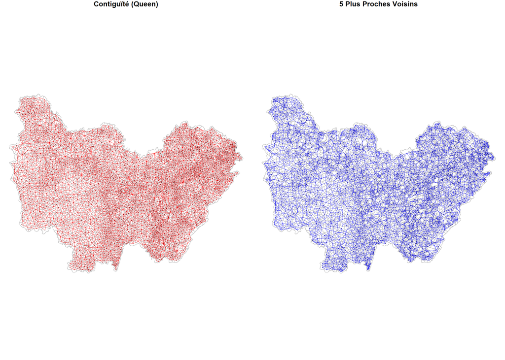

## 3 Analyse descriptive des variables expliquées

Cette section se concentre sur les deux variables expliquées du projet : 1. **Dépenses de fonctionnement** (variable `lCFT_COM`) 2. **Dépenses d’investissement** (variable `lDIT_COM`)

*Ces deux variables sont en échelle logarithmique, avec l’unité euros/hab.*

### 3.1 Statistiques descriptives

Nous commençons par observer la distribution des données (tendance centrale, dispersion) et leur forme via des histogrammes.

```
##     lCFT_COM        lDIT_COM
##  Min.   :5.629   Min.   : 0.000
##  1st Qu.:6.871   1st Qu.: 5.897
##  Median :7.107   Median : 6.451
##  Mean   :7.140   Mean   : 6.435
##  3rd Qu.:7.377   3rd Qu.: 7.021
##  Max.   :9.448   Max.   :10.003
```

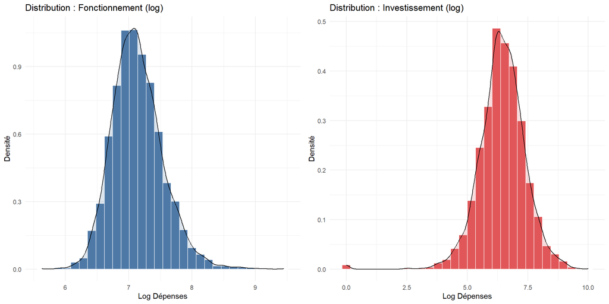

### 3.2 Cartographie des dépenses

Voyons maintenant cela sur une carte.

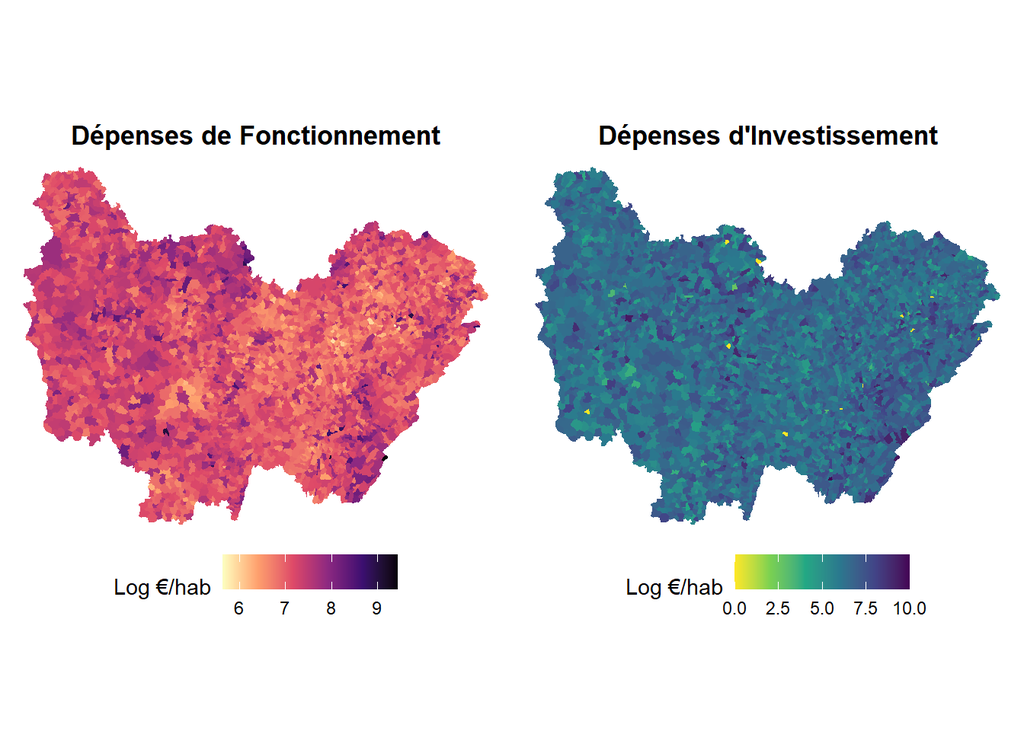

### 3.3 Autocorrélation spatiale globale (Moran)

Nous utilisons le test de Moran pour confirmer statistiquement si les dépenses sont distribuées de manière aléatoire ou groupée dans l’espace. Nous utilisons la matrice de contiguïté (`listw_queen`) créée précédemment.

```
## --- Résultat Moran : Fonctionnement ---
```

```
##
##  Moran I test under randomisation
##
## data:  comBFC$lCFT_COM
## weights: listw_queen
##
## Moran I statistic standard deviate = 33.094, p-value < 2.2e-16
## alternative hypothesis: greater
## sample estimates:
## Moran I statistic       Expectation          Variance
##      3.183677e-01     -2.612330e-04      9.269689e-05
```

```
##
## --- Résultat Moran : Investissement ---
```

```
##
##  Moran I test under randomisation
##
## data:  comBFC$lDIT_COM
## weights: listw_queen
##
## Moran I statistic standard deviate = 7.4802, p-value = 3.711e-14
## alternative hypothesis: greater
## sample estimates:
## Moran I statistic       Expectation          Variance
##      7.171825e-02     -2.612330e-04      9.259587e-05
```

### 3.4 Statistiques LISA

Les cartes LISA permettent d’identifier où se trouvent les clusters significatifs (Hotspots et Coldspots).

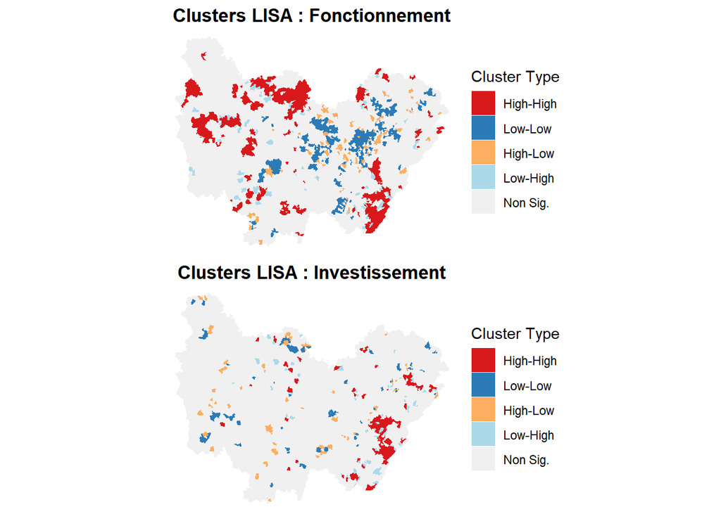

## 4 Analyse descriptive des variables explicatives

Dans cette section, nous analysons les déterminants potentiels des dépenses publiques locales.

### 4.1 Signes attendus

Nous avons retenu les variables suivantes en fonction de la littérature économique sur les finances locales. Voici les impacts attendus sur les dépenses :

| Variable | Description | Signe attendu | Justification Économique |
| --- | --- | --- | --- |
| `lPMUN` | Log Population | **+** | **Effet de taille** : Une population plus grande nécessite plus d’infrastructures et de services (“charges de centralité”). |
| `lEMPLT` | Log Emploi sur place | **+** | **Attractivité économique** : Les pôles d’emploi attirent des usagers non-résidents qui consomment des services publics (transports, voirie). |
| `prod_3_taxe_com` | Potentiel fiscal | **+** | **Effet richesse** : Plus une commune a une base fiscale élevée, plus elle a la capacité de dépenser (Loi de Wagner). |
| `TXX_CHOM1564` | Taux de chômage | **+** | **Besoins sociaux** : Un chômage élevé accroît la demande d’interventions sociales (CCAS, aides). |
| `TXX_RP_LOCHLMV` | Taux de logements HLM | **+** | **Précarité** : Indicateur de besoins sociaux spécifiques et de charges de gestion urbaine plus lourdes. |
| `TXX_ENDET` | Taux d’endettement | **-** | **Contrainte financière** : Un stock de dette élevé génère des charges d’intérêts qui peuvent évincer les autres dépenses (effet “ciseau”). |
| `TXX_RSECOCC` | Taux de résidences secondaires | **+** | **Tourisme** : Indique une vocation touristique nécessitant des suréquipements par rapport à la population permanente. |

### 4.2 Cartographie des variables clés

Nous choisissons de cartographier deux dimensions opposées mais complémentaires des finances locales : 1. **La richesse (Ressources)** : Via le potentiel fiscal (`prod_3_taxe_com`). Cela permet de visualiser les inégalités territoriales de revenus. 2. **La précarité (Besoins)** : Via le taux de chômage (`TXX_CHOM1564`). Cela permet d’identifier les zones en difficulté sociale.

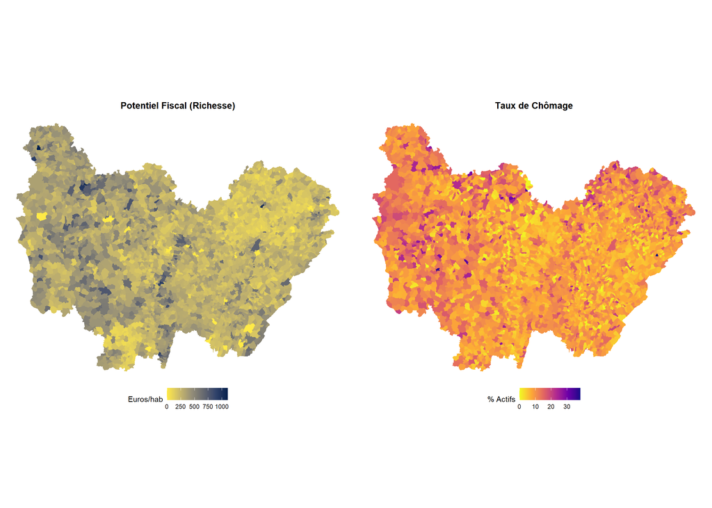

### 4.3 Estimation d’un modèle de régression linéaire – MCO

```r
# Définition de la formule de base
# Nous incluons les variables identifiées dans l'analyse descriptive
formule <- lCFT_COM ~ lPMUN + lEMPLT + prod_3_taxe_com + TXX_CHOM1564 + TXX_RP_LOCHLMV + TXX_ENDET + TXX_RSECOCC + factor(DEP)

### Estimation MCO
model_ols_fonc <- lm(formule, data = comBFC)
model_ols_inv  <- lm(update(formule, lDIT_COM ~ .), data = comBFC)

# Affichage des résultats
screenreg(list(model_ols_fonc, model_ols_inv),
          custom.model.names = c("Fonctionnement (MCO)", "Investissement (MCO)"),
          omit.coef = "factor\\(DEP\\)")
```

```
##
## ===========================================================
##                  Fonctionnement (MCO)  Investissement (MCO)
## -----------------------------------------------------------
## (Intercept)         7.41 ***              5.78 ***
##                    (0.05)                (0.13)
## lPMUN              -0.22 ***             -0.15 ***
##                    (0.01)                (0.03)
## lEMPLT              0.11 ***              0.18 ***
##                    (0.01)                (0.02)
## prod_3_taxe_com     0.00 ***              0.00 ***
##                    (0.00)                (0.00)
## TXX_CHOM1564        0.01 ***              0.01
##                    (0.00)                (0.00)
## TXX_RP_LOCHLMV      0.02 ***             -0.00
##                    (0.00)                (0.00)
## TXX_ENDET          -0.01                  0.33 ***
##                    (0.01)                (0.02)
## TXX_RSECOCC         0.01 ***              0.01 ***
##                    (0.00)                (0.00)
## -----------------------------------------------------------
## R^2                 0.37                  0.15
## Adj. R^2            0.37                  0.14
## Num. obs.        3829                  3829
## ===========================================================
## *** p < 0.001; ** p < 0.01; * p < 0.05
```

```r
### Diagnostics de Moran sur les résidus
# Il est crucial de tester si les résidus MCO sont spatialement autocorrélés
lm.morantest(model_ols_fonc, listw_queen)
```

```
##
##  Global Moran I for regression residuals
##
## data:
## model: lm(formula = formule, data = comBFC)
## weights: listw_queen
##
## Moran I statistic standard deviate = 22.24, p-value < 2.2e-16
## alternative hypothesis: greater
## sample estimates:
## Observed Moran I      Expectation         Variance
##     2.106986e-01    -2.433890e-03     9.183829e-05
```

Le modèle MCO initial montre que la population et le potentiel fiscal expliquent une part importante des dépenses. Cependant, le test de Moran sur les résidus est hautement significatif ($p < 0.001$), confirmant une autocorrélation spatiale non captée. Le modèle MCO est donc incomplet car il ignore les interactions de voisinage, ce qui impose le recours à l’économétrie spatiale.

## 5 Estimation d’un modèle SAR

Le modèle SAR (Spatial Autoregressive) suppose que les dépenses d’une commune dépendent des dépenses de ses voisines (effet de mimétisme).
$$y = \rho Wy + X\beta +
\varepsilon$$

```r
### Estimation par Maximum de Vraisemblance (ML)
# Fonctionnement
sar_ml_fonc <- lagsarlm(formule, data = comBFC, listw = listw_queen, method = "Matrix") #<- Matrix car sinon beaucoup trop long

### Estimation par les Moindres Carrés Doubles Spatiaux (2SLS) - Plus robuste à la non-normalité
sar_2sls_fonc <- stsls(formule, data = comBFC, listw = listw_queen)

### Modèle avec hétérogénéité du coefficient spatial par département
# On utilise ici l'interaction entre la matrice de poids et le facteur département
# (Note : Cette étape nécessite souvent une décomposition de la matrice W par bloc-département)

# Résumé des résultats SAR pour le fonctionnement
summary(sar_ml_fonc)
```

```
##
## Call:lagsarlm(formula = formule, data = comBFC, listw = listw_queen,
##     method = "Matrix")
##
## Residuals:
##       Min        1Q    Median        3Q       Max
## -1.187765 -0.191966 -0.016845  0.160052  2.102807
##
## Type: lag
## Coefficients: (numerical Hessian approximate standard errors)
##                    Estimate  Std. Error  z value  Pr(>|z|)
## (Intercept)      4.8501e+00  1.3972e-01  34.7123 < 2.2e-16
## lPMUN           -1.9341e-01  1.0363e-02 -18.6629 < 2.2e-16
## lEMPLT           9.5817e-02  7.5047e-03  12.7676 < 2.2e-16
## prod_3_taxe_com  7.2913e-04  4.5589e-05  15.9935 < 2.2e-16
## TXX_CHOM1564     5.8359e-03  1.1648e-03   5.0101 5.440e-07
## TXX_RP_LOCHLMV   2.1203e-02  1.3622e-03  15.5654 < 2.2e-16
## TXX_ENDET       -5.1187e-03  5.9550e-03  -0.8596  0.390027
## TXX_RSECOCC      5.5018e-03  5.5351e-04   9.9398 < 2.2e-16
## factor(DEP)25    8.8088e-02  1.6886e-02   5.2168 1.821e-07
## factor(DEP)39    1.7090e-02  1.6342e-02   1.0457  0.295683
## factor(DEP)58   -2.1383e-02  2.2456e-02  -0.9522  0.340994
## factor(DEP)70    7.7724e-02  1.7706e-02   4.3896 1.135e-05
## factor(DEP)71    1.7402e-02  1.5916e-02   1.0934  0.274235
## factor(DEP)89    5.5431e-02  1.8543e-02   2.9893  0.002796
## factor(DEP)90    5.1215e-02  3.2561e-02   1.5729  0.115747
##
## Rho: 0.35559, LR test value: 328.98, p-value: < 2.22e-16
## Approximate (numerical Hessian) standard error: 0.018526
##     z-value: 19.194, p-value: < 2.22e-16
## Wald statistic: 368.42, p-value: < 2.22e-16
##
## Log likelihood: -892.8128 for lag model
## ML residual variance (sigma squared): 0.091157, (sigma: 0.30192)
## Number of observations: 3829
## Number of parameters estimated: 17
## AIC: 1819.6, (AIC for lm: 2146.6)
```

### 5.1 Analyse des impacts (Effets Directs et Indirects)

Dans un modèle spatial, le coefficient $\beta$ ne représente pas l’effet total.

```r
W_mat <- as(listw_queen, "CsparseMatrix")
impacts_sar <- impacts(sar_ml_fonc, listw = listw_queen, R = 500)
summary(impacts_sar, zstats = TRUE, short = TRUE)
```

```
## Impact measures (lag, exact):
##                              Direct     Indirect        Total
## lPMUN dy/dx           -0.1982991615 -0.101839379 -0.300138540
## lEMPLT dy/dx           0.0982386086  0.050451847  0.148690455
## prod_3_taxe_com dy/dx  0.0007475577  0.000383919  0.001131477
## TXX_CHOM1564 dy/dx     0.0059833761  0.003072849  0.009056225
## TXX_RP_LOCHLMV dy/dx   0.0217389140  0.011164331  0.032903245
## TXX_ENDET dy/dx       -0.0052480651 -0.002695219 -0.007943284
## TXX_RSECOCC dy/dx      0.0056407894  0.002896908  0.008537698
## factor(DEP)25 dy/dx    0.0903138096  0.046381952  0.136695762
## factor(DEP)39 dy/dx    0.0175216336  0.008998486  0.026520120
## factor(DEP)58 dy/dx   -0.0219231175 -0.011258931 -0.033182049
## factor(DEP)70 dy/dx    0.0796876287  0.040924725  0.120612353
## factor(DEP)71 dy/dx    0.0178415023  0.009162759  0.027004262
## factor(DEP)89 dy/dx    0.0568315770  0.029186672  0.086018249
## factor(DEP)90 dy/dx    0.0525086643  0.026966578  0.079475242
## ========================================================
## Simulation results ( variance matrix):
## ========================================================
## Simulated standard errors
##                             Direct     Indirect        Total
## lPMUN dy/dx           1.056321e-02 8.860802e-03 1.699140e-02
## lEMPLT dy/dx          7.403605e-03 5.102744e-03 1.150126e-02
## prod_3_taxe_com dy/dx 4.580556e-05 3.644114e-05 7.408412e-05
## TXX_CHOM1564 dy/dx    1.160045e-03 6.066398e-04 1.737593e-03
## TXX_RP_LOCHLMV dy/dx  1.420608e-03 1.146946e-03 2.363687e-03
## TXX_ENDET dy/dx       6.020013e-03 3.149726e-03 9.159050e-03
## TXX_RSECOCC dy/dx     5.514531e-04 3.248542e-04 8.254493e-04
## factor(DEP)25 dy/dx   1.746628e-02 9.575241e-03 2.659749e-02
## factor(DEP)39 dy/dx   1.706424e-02 8.876238e-03 2.590904e-02
## factor(DEP)58 dy/dx   2.416428e-02 1.259471e-02 3.671850e-02
## factor(DEP)70 dy/dx   1.813682e-02 1.032077e-02 2.815677e-02
## factor(DEP)71 dy/dx   1.713247e-02 8.916015e-03 2.601659e-02
## factor(DEP)89 dy/dx   1.991142e-02 1.029469e-02 3.004172e-02
## factor(DEP)90 dy/dx   3.253968e-02 1.691735e-02 4.934161e-02
##
## Simulated z-values:
##                            Direct    Indirect       Total
## lPMUN dy/dx           -18.8042901 -11.5936639 -17.7362039
## lEMPLT dy/dx           13.2621050   9.9504029  12.9517748
```

[output cut: 14 more lines]

```
##                       Direct     Indirect   Total
## lPMUN dy/dx           < 2.22e-16 < 2.22e-16 < 2.22e-16
## lEMPLT dy/dx          < 2.22e-16 < 2.22e-16 < 2.22e-16
## prod_3_taxe_com dy/dx < 2.22e-16 < 2.22e-16 < 2.22e-16
## TXX_CHOM1564 dy/dx    3.4346e-07 4.8663e-07 2.4686e-07
## TXX_RP_LOCHLMV dy/dx  < 2.22e-16 < 2.22e-16 < 2.22e-16
## TXX_ENDET dy/dx       0.3877379  0.392913   0.3889577
## TXX_RSECOCC dy/dx     < 2.22e-16 < 2.22e-16 < 2.22e-16
## factor(DEP)25 dy/dx   3.3806e-07 1.4987e-06 3.7381e-07
## factor(DEP)39 dy/dx   0.3188990  0.320556   0.3188784
## factor(DEP)58 dy/dx   0.3620194  0.366210   0.3629230
## factor(DEP)70 dy/dx   1.8337e-05 9.4551e-05 2.7810e-05
## factor(DEP)71 dy/dx   0.3118381  0.314983   0.3123194
## factor(DEP)89 dy/dx   0.0046391  0.004726   0.0044476
## factor(DEP)90 dy/dx   0.1009098  0.103023   0.1008312
```

## 6 Estimation d’un modèle de Durbin avec la population et l’emploi en variables décalées

Le modèle de Durbin est le plus complet : il inclut le retard spatial de la variable dépendante ($Wy$) ET le retard spatial des variables explicatives ($WX$). Nous nous focalisons sur les lags de la population et de l’emploi.

```r
# On définit les variables à décaler spatialement (Population et Emploi)
sdm_fonc <- lagsarlm(formule, data = comBFC, listw = listw_queen,
                     Durbin = ~ lPMUN + lEMPLT, method = "Matrix")

# Comparaison SAR vs SDM (Test de rapport de vraisemblance)
LR.Sarlm(sdm_fonc, sar_ml_fonc)
```

```
##
##  Likelihood ratio for spatial linear models
##
## data:
## Likelihood ratio = 12.144, df = 2, p-value = 0.002306
## sample estimates:
##    Log likelihood of sdm_fonc Log likelihood of sar_ml_fonc
##                     -886.7406                     -892.8128
```

## 7 Conclusion

L’analyse démontre que les finances locales en Bourgogne-Franche-Comté sont interdépendantes. La présence de clusters spatiaux et la significativité des effets de débordement suggèrent que les politiques de dépenses ne doivent plus être pensées de manière isolée, mais à l’échelle des bassins de vie pour optimiser la gestion des équipements publics.